# Auto-correlación

Santiago Bohorquez Correa Universidad EAFIT Escuela de Finanzas, Economía y Gobierno

- Una de las principales características de las series de tiempo es la presencia de Auto-correlación o correlación serial.
- Ustedes posiblemente están familiarizados con el concepto de correlación entre dos variables, la auto-correlación implica correlación entre la serie y su pasado.

Si la secuencia aleatoria $\{x_t\}$ tiene media $E[x_t]=\mu_t$ la autocovarianza esta dada por:
$$\begin{equation}
\begin{matrix}
cov[x_{t_1},x_{t_2}] & = &
E[(x_{t_1}-\mu_{t_1})(x_{t_2}-\mu_{t_2})] \\
& = & E[(x_{t_1}x_{t_2})] - \mu_{t_1}\mu_{t_2}
\end{matrix}
\end{equation}$$

## Autocovarianza

$$\begin{equation}
\begin{matrix}
E[(x_{t_1}-\mu_{t_1})(x_{t_2}-\mu_{t_2})] = E[(x_{t_1}x_{t_2} -
x_{t_1}\mu_{t_2} - \mu_{t_1}x_{t_2} + \mu_{t_1}\mu_{t_2})] \\
= E[x_{t_1}x_{t_2}] - E[x_{t_1}\mu_{t_2}] - E[\mu_{t_1}x_{t_2}] +
E[\mu_{t_1}\mu_{t_2}] \\
= E[x_{t_1}x_{t_2}] - E[x_{t_1}]\mu_{t_2} - \mu_{t_1}E[x_{t_2}]
+ \mu_{t_1}\mu_{t_2} \\
= E[x_{t_1}x_{t_2}] - \mu_{t_1}\mu_{t_2} - \mu_{t_1}\mu_{t_2} +
\mu_{t_1}\mu_{t_2} \\
= E[x_{t_1}x_{t_2}] - \mu_{t_1}\mu_{t_2}
\end{matrix}
\end{equation}$$

La autocovarianza de orden $j$ se define como;

$$\begin{equation}
\gamma_j = cov(x_{t},x_{t-j}) = E[(x_{t}x_{t-j})] - \mu_{t}\mu_{t-j}
\end{equation}$$

Ahora, definimos la auto-correlación como

$$\begin{equation}
\rho_j = \frac{\gamma_j}{\gamma_0}
\end{equation}$$

La ventaja de usar la auto-correlación en vez de la auto-covarianza es que la auto-correlación siempre va a estar entre -1 y 1, dado que la covarianza siempre es igual o menor en valor absoluto que la varianza.

Las auto-covarianzas y auto-correlaciones expuestas anteriormente son los valores poblacionales, estas pueden ser estimadas en una muestra de tamaño $T$ de la siguiente manera:
$$\begin{align}
\hat{\gamma_j} = & \frac{1}{T} \sum^T_{t=j+1} (x_t -
\bar{x}_{j+1:T})(x_{t-j} - \bar{x}_{1:T-j}) \\
\hat{\rho_j} = & \frac{\hat{\gamma_j}}{\widehat{var(x_t)}}
\end{align}$$

- donde $\bar{x}_{j+1:T}$ es el promedio muestral de $x_t$ usando las observaciones $t=j+1,j+2,\dots,T$
- $\widehat{var(x_t)}=\frac{1}{T-1}\Sigma_{i=1}^T(x_i-\bar{x})^2$ es la varianza muestral de $x_t$.
- Noten que la ecuación de la auto-covarianza se divide por $T$ y no $T-j$ como es usual cuando perdemos grados de libertad, la razón para esto es para poder hacer comparaciones entre diferentes ordenes de las auto-covarianzas.

Vemos un ejemplo de una serie de tiempo con auto-correlación:

El crecimiento del PIB trimestral para EEUU.

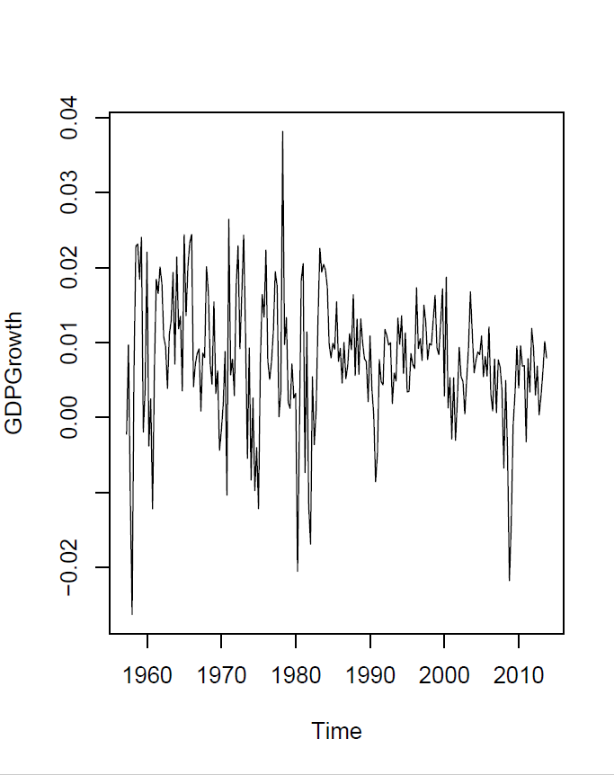

- En nuestro ejemplo de crecimiento del PIB las autocorrelaciones muestrales son, $\hat{\rho_1}=0.34$, $\hat{\rho_2}=0.27$, $\hat{\rho_3}=0.13$, $\hat{\rho_4}=0.14$.
- Estos valores sugieren que el crecimiento del PIB esta levemente correlacionado positivamente.
- Esto implica que si el PIB crece más (menos) que el promedio en un periodo, este tiende a crecer más (menos) que el promedio el periodo siguiente.
- Claramente, si la autocorrelación es distinta de cero los supuestos de MCO no se cumplen.
- Por esta razón se han escrito innumerables artículos de investigación sobre como testear por correlación serial en modelos de regresión.
- La forma más sencilla de hacerlo es testeando la hipótesis nula de no correlación serial versus la alternativa de correlación serial de algún orden.

# Test correlación serial

Supongamos el siguiente modelo de regresión lineal,
$$\begin{equation}
y_t = \mathbf{X}_t \boldsymbol{\beta} + u_t, \quad u_t = \rho
u_{t-1} + \varepsilon_t, \quad \varepsilon_t \sim
IID(0,\sigma^2_{\varepsilon})
\end{equation}$$

es decir, el termino de error $u_t$ sigue un proceso AR(1).

Como veremos cuando analicemos los modelos Autorregresivos debemos imponer la restricción $|\rho|<1$.

Sustituyendo $u_t$ por $\rho u_{t-1} + \varepsilon_t$,

$$\begin{equation}
y_t = \mathbf{X}_t \boldsymbol{\beta} + \rho u_{t-1} +
\varepsilon_t
\end{equation}$$

Y remplazando $u_{t-1}$ por $y_{t-1} - \mathbf{X}_{t-1} \boldsymbol{\beta}$,
$$\begin{equation}
y_t = \rho y_{t-1} + \mathbf{X}_t \boldsymbol{\beta} -
\rho\mathbf{X}_{t-1} \boldsymbol{\beta} + \varepsilon_t
\end{equation}$$

- Como la variable dependiente rezagada, $y_{t-1}$, entra dentro de los regresores nos referimos a este modelo como un modelo *dinámico* .
- Para este modelo perdemos el primer dato de la muestra ya que en este caso no conoceríamos el rezago para dicho momento.
- Este modelo es lineal en los regresores, pero no es lineal en los parámetros, y por lo tanto debería ser estimado por Mínimos Cuadrados no lineales.

# Test correlación serial - Gauss Newton

Podemos evitar hacer esta estimación no lineal, si hacemos un test basándonos en la regresión de Gauss-Newton.

Primero estimamos por MCO la regresión:
$$\begin{equation}
y_t = \mathbf{X}_t \boldsymbol{\beta} + u_t
\end{equation}$$

Sea $\tilde{u}$ el vector de residuales de la regresión anterior.

Con esto, el test consiste en probar la hipótesis nula de $b_p = 0$ en la regresión,
$$\begin{equation}
\tilde{u}_t = b_p \tilde{u}_{t-1} + residuales
\end{equation}$$
donde $b_p \sim N(0,1)$ bajo la hipótesis nula.

# Test correlación serial - Otros Tests

**Yule-Walker Test:** Calculamos la autocorrelación de los residuales,
$$\begin{equation}
\hat{\rho}_j = \frac{\hat{\gamma}_j}{\hat{\gamma}_0}
\end{equation}$$
testeamos $\hat{\rho}_j = 0$ con $Var(\hat{\rho}_j) = \frac{1}{T}$.